# IPF Trial run analysis on slide 0020227

This is a slide that was run in December 2023. The slide includes one section from the same block (the “good” block) done with the limited library on 0010972 that gave some decent data. One triangular piece is a scleroderma lung.

# Environment

```r
library(Seurat)
library(tidyverse)
```

# Read in Xenium

```r
ipf3.xen <- LoadXenium('output-XETG00143__0020227__Region_1__20231214__022306/')
```

[output not shown]

# Identify cells as if normal single cell

An important caveat to this dataset is that a portion of these cells are from scleroderma lung.

## First pass

```r
DefaultAssay(ipf3.xen) <- 'Xenium'
ipf3.xen <- NormalizeData(ipf3.xen)
```

```
Normalizing layer: counts
```

```r
ipf3.xen <- FindVariableFeatures(ipf3.xen)
```

```
Finding variable features for layer counts
```

```r
ipf3.xen <- ScaleData(ipf3.xen)
ipf3.xen <- RunPCA(ipf3.xen, npcs = 30, features = rownames(ipf3.xen))
```

```
PC_ 1
Positive:  MYH11, DES, LMOD1, PDGFRB, CRISPLD2, POSTN, VWF, CNN1, COL1A1, COL5A2
       SFRP2, FBN1, INMT, NID1, THBS2, SCN7A, RGS5, APOD, FGFR4, GJA5
       PLN, PDGFRA, ITGA1, KIT, SLC18A2, ADAMTS1, CTHRC1, FCN3, LTBP2, SVEP1
Negative:  MUC1, TMPRSS2, ABCA3, ITGB6, CDH1, SFTPD, ATP1B1, KRT8, ALOX15B, DMBT1
       KRT7, STEAP4, DUOX1, TMC5, AGR2, MALL, PLA2G4F, EHF, FASN, BAIAP2L1
       PEBP4, F3, EPCAM, MYO6, CEACAM6, XBP1, SCEL, KLF5, FAM184A, GKN2
PC_ 2
Positive:  MUC1, ABCA3, ITGB6, TMPRSS2, SFTPD, DMBT1, STEAP4, CDH1, DUOX1, MALL
       TMC5, ALOX15B, AGR2, BAIAP2L1, F3, KRT7, CTTN, PEBP4, FAM184A, PLA2G4F
       EHF, TC2N, FASN, KLF5, GKN2, MTUS1, CEACAM6, EPCAM, PDE4D, TACSTD2
Negative:  MARCO, VSIG4, CD68, CD163, FCGR3A, PCOLCE2, MCEMP1, MS4A4A, CTSL, ANPEP
       AIF1, IRF8, NCEH1, AQP9, LGALS3, CXCL5, FCGR1A, GLIPR2, ITGAM, HAVCR2
       SYK, S100A9, FABP3, SLC1A3, MPEG1, CD86, PLA2G7, CSTA, CD14, IFI6
PC_ 3
Positive:  COL1A1, LTBP2, FBN1, CRISPLD2, COL5A2, PDGFRB, ENAH, NID1, THBS2, DUSP1
       ADAMTS1, SLIT3, SPRY1, CTTN, MYH11, SCN7A, VWF, ITGA1, PDGFRA, LMOD1
       SVEP1, INMT, GJA5, SHANK3, POSTN, FGFR4, HIF1A, DES, FAS, RARRES1
Negative:  DMBT1, ABCA3, SFTPD, ALOX15B, MARCO, TMPRSS2, MUC1, PEBP4, PLA2G4F, ITGB6
       CSF3R, GKN2, VSIG4, SFTA2, DUOX1, S100A8, CDH1, MCEMP1, CD38, CXCL5
       MALL, AQP9, FCGR3A, AGR2, STEAP4, CD163, CD68, ATP1B1, SCEL, S100A9
PC_ 4
Positive:  MUC5B, CP, LTF, KLK11, ELF3, CCDC78, ERN2, ALOX15, EHF, ITGB4
       CD24, TMC5, AGR2, FOXJ1, TACSTD2, KLF5, TSPAN8, SOX2, CYP2F1, MUC16
       ADAM28, KRT15, CFTR, KRT7, SLC15A2, TP73, CEACAM6, SLC2A1, BAIAP2L1, TC2N
Negative:  ABCA3, ALOX15B, SFTPD, DMBT1, PLA2G4F, PEBP4, FASN, GKN2, CSF3R, ITGB6
       ETV5, SFTA2, COL8A1, MALL, FAM184A, COL1A1, AREG, LTBP2, CD38, TMPRSS2
       COL5A2, HMGCS1, PDGFRB, SCEL, THBS2, ERN1, CRISPLD2, NID1, FBN1, PDE4D
PC_ 5
Positive:  SHANK3, VWF, TMEM100, ECSCR, FCN3, ACE, RAMP2, RGS5, CD34, SELP
       PLVAP, ACKR1, GNG11, SMAD6, ADGRL4, CLDN5, MMRN1, NTRK2, ITGA6, EGLN3
       DUSP1, IL33, IL7R, LYVE1, SMAD7, KDR, MTUS1, ARRDC2, ITGB4, BAIAP2L1
Negative:  COL1A1, LTBP2, THBS2, COL5A2, SLC18A2, KIT, MS4A2, PDGFRA, RARRES1, IL1RL1
       FBN1, SFRP2, SCN7A, SVEP1, MUC5B, IGF1, CRISPLD2, HPGDS, MEDAG, FAS
       APOD, CNN1, P2RX1, FGFR4, PLA2G2A, TSPAN8, DES, KLK11, CP, COL8A1
```

```r
ipf3.xen <- RunUMAP(ipf3.xen, dims = 1:30)
ipf3.xen <- FindNeighbors(ipf3.xen, reduction = "pca", dims = 1:30)
```

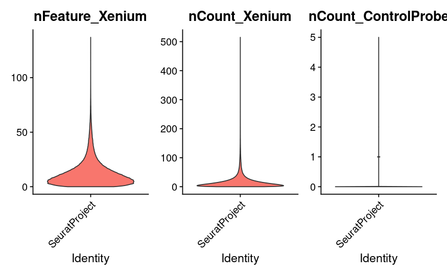

```r
VlnPlot(ipf3.xen, pt.size = 0,
        features=c("nFeature_Xenium", "nCount_Xenium", "nCount_ControlProbe"))
```

```
Rasterizing points since number of points exceeds 100,000.
To disable this behavior set `raster=FALSE`
```

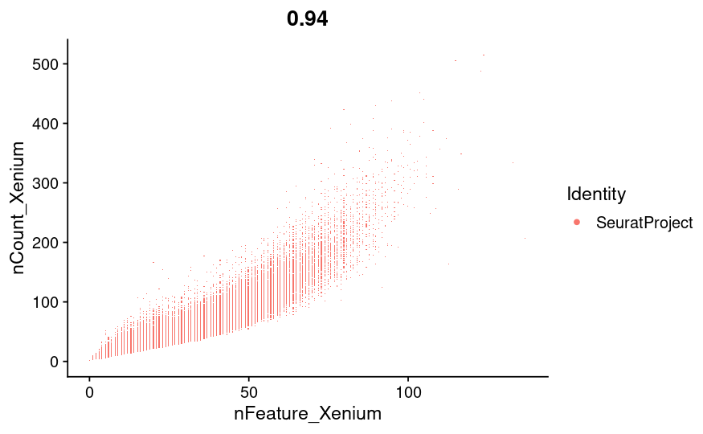

```r
FeatureScatter(ipf3.xen, "nFeature_Xenium", "nCount_Xenium")
```

```
Rasterizing points since number of points exceeds 100,000.
To disable this behavior set `raster=FALSE`
Rasterizing points since number of points exceeds 100,000.
To disable this behavior set `raster=FALSE`
Rasterizing points since number of points exceeds 100,000.
To disable this behavior set `raster=FALSE`
Warning: All cells have the same value (1) of “nCount_ControlProbe”Rasterizing points since number of points exceeds 100,000.
To disable this behavior set `raster=FALSE`
Warning: All cells have the same value (1) of “nFeature_ControlProbe”Rasterizing points since number of points exceeds 100,000.
To disable this behavior set `raster=FALSE`
Rasterizing points since number of points exceeds 100,000.
To disable this behavior set `raster=FALSE`
```

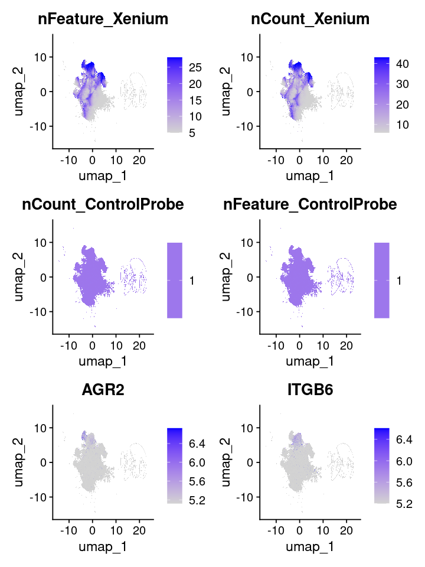

```r
FeaturePlot(ipf3.xen, features = c("nFeature_Xenium", "nCount_Xenium", "nCount_ControlProbe", "nFeature_ControlProbe", 'AGR2','ITGB6'), min.cutoff='q25', max.cutoff='q90')
```

```
Rasterizing points since number of points exceeds 100,000.
To disable this behavior set `raster=FALSE`
Rasterizing points since number of points exceeds 100,000.
To disable this behavior set `raster=FALSE`
Rasterizing points since number of points exceeds 100,000.
To disable this behavior set `raster=FALSE`
Rasterizing points since number of points exceeds 100,000.
To disable this behavior set `raster=FALSE`
Rasterizing points since number of points exceeds 100,000.
To disable this behavior set `raster=FALSE`
Rasterizing points since number of points exceeds 100,000.
To disable this behavior set `raster=FALSE`
```

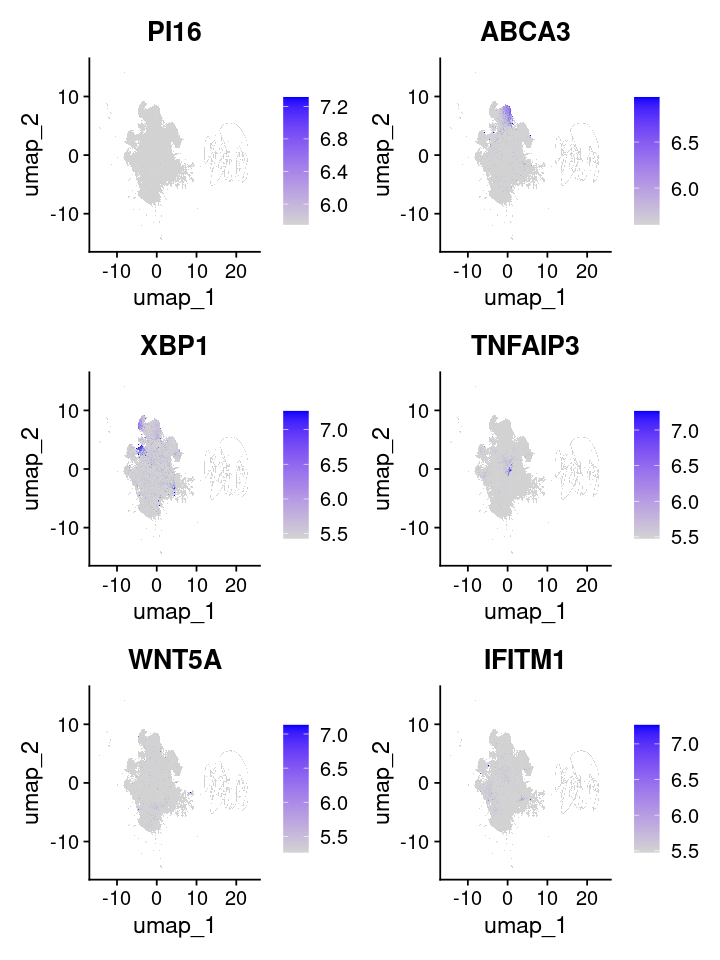

```r
FeaturePlot(ipf3.xen, features = c("PI16", "ABCA3", "XBP1", "TNFAIP3", "WNT5A", "IFITM1"), min.cutoff='q25', max.cutoff='q90')
```

```
Rasterizing points since number of points exceeds 100,000.
To disable this behavior set `raster=FALSE`
Rasterizing points since number of points exceeds 100,000.
To disable this behavior set `raster=FALSE`
Rasterizing points since number of points exceeds 100,000.
To disable this behavior set `raster=FALSE`
Rasterizing points since number of points exceeds 100,000.
To disable this behavior set `raster=FALSE`
Rasterizing points since number of points exceeds 100,000.
To disable this behavior set `raster=FALSE`
Rasterizing points since number of points exceeds 100,000.
To disable this behavior set `raster=FALSE`
```

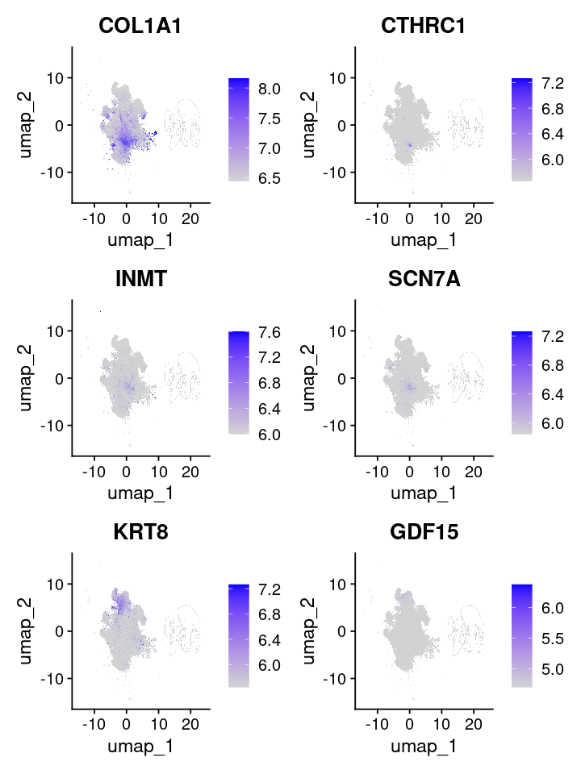

```r
FeaturePlot(ipf3.xen, features = c("COL1A1", "CTHRC1", "INMT", "SCN7A", "KRT8", "GDF15"), min.cutoff='q25', max.cutoff='q90')
```

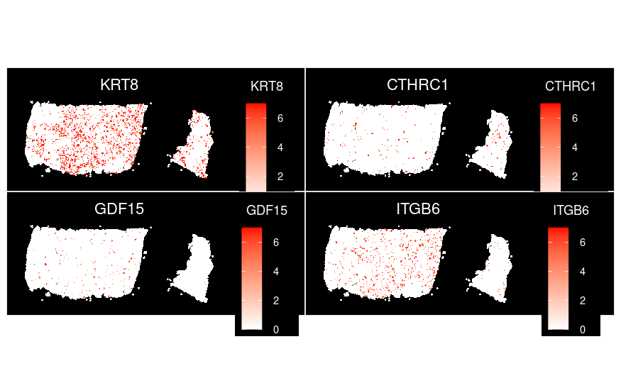

```r
ImageFeaturePlot(ipf3.xen, features = c("KRT8", "CTHRC1", "GDF15", "ITGB6"), max.cutoff = c(7,
    7, 7, 7), size = 0.75, cols = c("white", "red"))
```

## Subset somewhat strictly on feature count

On the theory that if there was only few features, but they had counts, it is probably still interpretable.

```r
ipf3.filtered.xen <- subset(ipf3.xen, subset=nCount_Xenium>20 & nFeature_Xenium>4)
```

```
Rasterizing points since number of points exceeds 100,000.
To disable this behavior set `raster=FALSE`
Rasterizing points since number of points exceeds 100,000.
To disable this behavior set `raster=FALSE`
Rasterizing points since number of points exceeds 100,000.
To disable this behavior set `raster=FALSE`
Warning: All cells have the same value (1) of “nCount_ControlProbe”Rasterizing points since number of points exceeds 100,000.
To disable this behavior set `raster=FALSE`
Warning: All cells have the same value (1) of “nFeature_ControlProbe”Rasterizing points since number of points exceeds 100,000.
To disable this behavior set `raster=FALSE`
Rasterizing points since number of points exceeds 100,000.
To disable this behavior set `raster=FALSE`
```

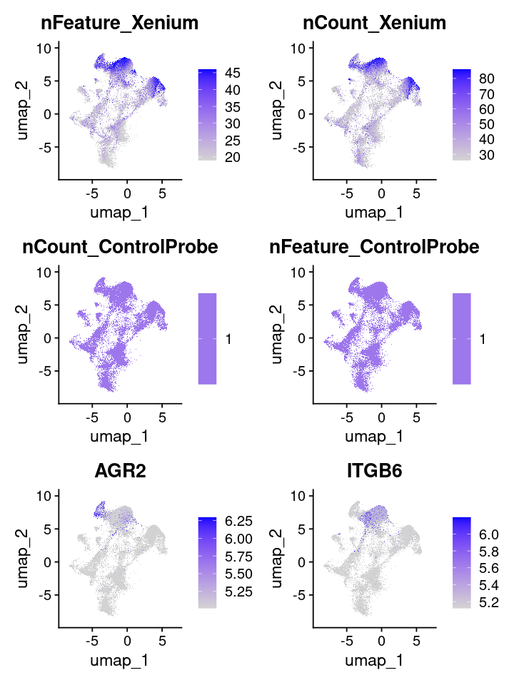

```r
FeaturePlot(ipf3.filtered.xen, features = c("nFeature_Xenium", "nCount_Xenium", "nCount_ControlProbe", "nFeature_ControlProbe", 'AGR2','ITGB6'), min.cutoff='q25', max.cutoff='q90')
```

```
Rasterizing points since number of points exceeds 100,000.
To disable this behavior set `raster=FALSE`
Rasterizing points since number of points exceeds 100,000.
To disable this behavior set `raster=FALSE`
Rasterizing points since number of points exceeds 100,000.
To disable this behavior set `raster=FALSE`
Rasterizing points since number of points exceeds 100,000.
To disable this behavior set `raster=FALSE`
Rasterizing points since number of points exceeds 100,000.
To disable this behavior set `raster=FALSE`
Rasterizing points since number of points exceeds 100,000.
To disable this behavior set `raster=FALSE`
```

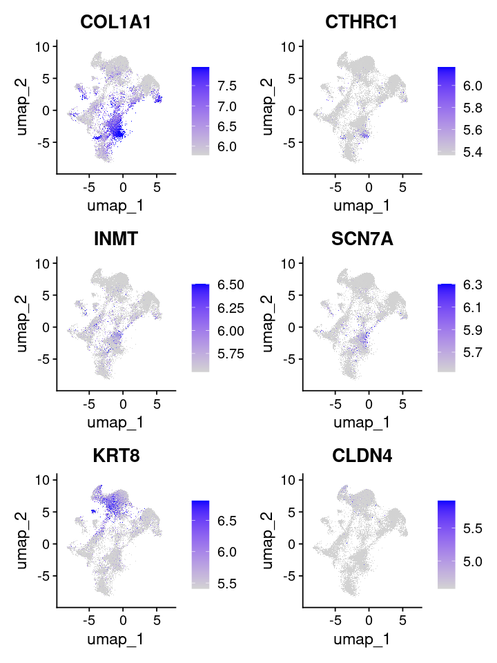

```r
FeaturePlot(ipf3.filtered.xen, features = c("COL1A1", "CTHRC1", "INMT", "SCN7A", "KRT8", "CLDN4"), min.cutoff='q25', max.cutoff='q90')
```

How manu cells did we filter out?

```r
print('original dataset:')
```

```
[1] "original dataset:"
```

```r
print(ncol(ipf3.xen))
```

```
[1] 580730
```

```r
print('filtered dataset:')
```

```
[1] "filtered dataset:"
```

```r
print(ncol(ipf3.filtered.xen))
```

```
[1] 158303
```

## Try to identify clusters of interesting cells

```r
ipf3.filtered.xen <- NormalizeData(ipf3.filtered.xen)
```

```
Normalizing layer: counts
```

```r
ipf3.filtered.xen <- FindVariableFeatures(ipf3.filtered.xen)
```

```
Finding variable features for layer counts
```

```r
ipf3.filtered.xen <- ScaleData(ipf3.filtered.xen)
ipf3.filtered.xen <- RunPCA(ipf3.filtered.xen, features = rownames(ipf3.filtered.xen))
```

```
PC_ 1
Positive:  MUC1, TMPRSS2, ABCA3, SFTPD, ITGB6, CDH1, DMBT1, STEAP4, KRT8, KRT7
       ALOX15B, DUOX1, BAIAP2L1, TMC5, PLA2G4F, MALL, AGR2, FASN, EHF, F3
       ATP1B1, PEBP4, EPCAM, FAM184A, TC2N, SCEL, MTUS1, CEACAM6, GKN2, KLF5
Negative:  CD68, CD163, VSIG4, MARCO, FCGR3A, AIF1, MS4A4A, IRF8, CTSL, MCEMP1
       PCOLCE2, ANPEP, ITGAM, CD4, GLIPR2, AQP9, FCGR1A, CD14, MPEG1, HAVCR2
       SLC1A3, IL7R, CXCL5, CD86, S100A8, NCEH1, ACE, CSTA, PLA2G7, FKBP5
PC_ 2
Positive:  COL1A1, MYH11, LTBP2, CRISPLD2, COL5A2, FBN1, PDGFRB, THBS2, LMOD1, ENAH
       DES, NID1, POSTN, VWF, ADAMTS1, CNN1, ITGA1, INMT, SCN7A, GJA5
       PDGFRA, RGS5, SHANK3, APOD, SFRP2, FGFR4, THY1, SVEP1, CD34, TMEM100
Negative:  MARCO, VSIG4, CD68, MCEMP1, FCGR3A, CD163, ANPEP, MS4A4A, LGALS3, AIF1
       PCOLCE2, IRF8, NCEH1, CTSL, AQP9, FCGR1A, SYK, HAVCR2, GLIPR2, CXCL5
       ITGAM, S100A9, FABP3, IFI6, CD86, S100A8, ATP1B1, PARP14, CSTA, SLC1A3
PC_ 3
Positive:  MUC5B, ERN2, CP, LTF, KLK11, ALOX15, CCDC78, MUC16, ELF3, FOXJ1
       CYP2F1, EHF, TSPAN8, TP73, CD24, ADAM28, TMC5, AGR2, SOX2, ITGB4
       TACSTD2, KRT15, KLF5, MUC5AC, CFTR, SLC15A2, SOX9, RARRES1, SLC2A1, ANPEP
Negative:  ABCA3, SFTPD, ALOX15B, DMBT1, PLA2G4F, PEBP4, GKN2, FASN, ITGB6, CSF3R
       ETV5, SFTA2, MALL, FAM184A, AREG, COL8A1, TMPRSS2, SCEL, CD38, HMGCS1
       ERN1, AGER, NTN4, MUC1, BANK1, RND1, MTUS1, STEAP4, TMEM100, TGFB1
PC_ 4
Positive:  COL1A1, LTBP2, THBS2, COL5A2, PDGFRA, FBN1, SCN7A, SFRP2, SVEP1, IGF1
       RARRES1, CRISPLD2, COL8A1, MEDAG, FAS, FGFR4, PLA2G2A, APOD, SLC18A2, MS4A2
       KIT, IL1RL1, THY1, DCLK1, CTHRC1, SLIT3, CD4, SEMA3C, HPGDS, ENAH
Negative:  VWF, SHANK3, ECSCR, TMEM100, FCN3, SELP, ACKR1, RGS5, PLVAP, ACE
       RAMP2, ADGRL4, MMRN1, CD34, GNG11, IL33, EGLN3, SMAD6, LYVE1, CLDN5
       DUSP1, ITGB4, ITGA6, KDR, NOS3, NTRK2, IL7R, APOLD1, BAIAP2L1, MTUS1
PC_ 5
Positive:  SLC18A2, KIT, MS4A2, IL1RL1, HPGDS, DES, PTGS1, P2RX1, MYH11, CNN1
       LMOD1, PLN, FCER1A, AREG, ADAMTS1, LGR6, DGKG, SIGLEC8, CCDC78, CLEC12A
       DMBT1, ADAM28, FOXJ1, ITGAM, MUC5B, ALOX15, CYP2F1, ABCA3, SFTPD, TP73
Negative:  COL1A1, LTBP2, COL5A2, FBN1, PDGFRA, SVEP1, SPRY1, SCN7A, FAS, SFRP2
       IGF1, POSTN, MEDAG, RARRES1, FGFR4, CRISPLD2, SLIT3, PLA2G2A, APOD, CTTN
       THY1, GJA5, COL8A1, INMT, CD34, THBS2, TRPC6, PDPN, ENAH, NID1
Warning: Number of dimensions changing from 30 to 50
```

```r
ipf3.filtered.xen <- RunUMAP(ipf3.filtered.xen, dims = 1:30)
```

```
Using method 'umap'
```

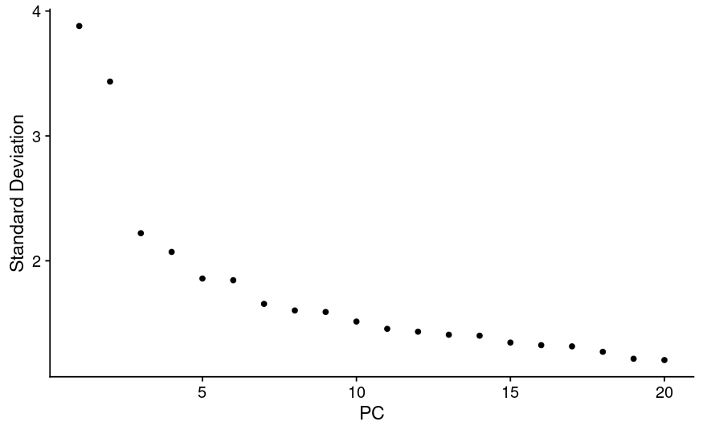

```r
ElbowPlot(ipf3.filtered.xen)
```

```r
# modification to reduce cluster number. i think the sparsity of data means that pruned edges leads to more communities.
ipf3.filtered.xen <- FindNeighbors(ipf3.filtered.xen, reduction='pca', dims=1:17) #, prune.SNN=0)
ipf3.filtered.xen <- FindClusters(ipf3.filtered.xen, resolution = 0.4)
```

```
Modularity Optimizer version 1.3.0 by Ludo Waltman and Nees Jan van Eck

Number of nodes: 158303
Number of edges: 4439307

Running Louvain algorithm...
```

```
Maximum modularity in 10 random starts: 0.9186
Number of communities: 17
Elapsed time: 89 seconds
```

```
1 singletons identified. 16 final clusters.
```

```
Rasterizing points since number of points exceeds 100,000.
To disable this behavior set `raster=FALSE`
```

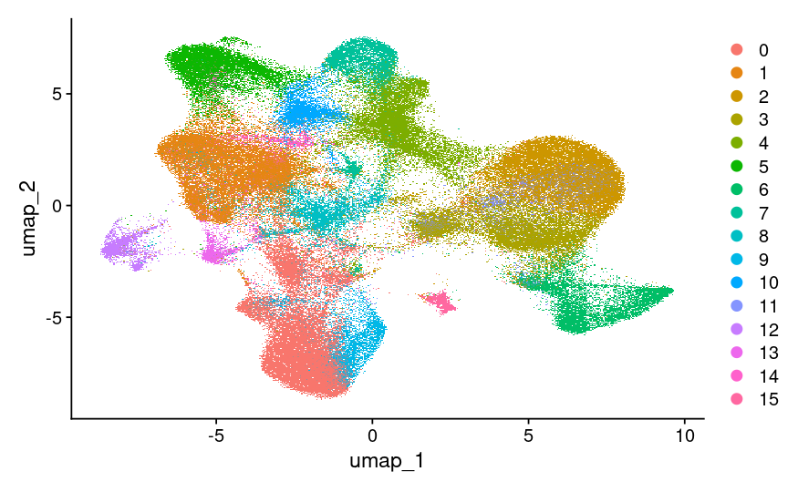

```r
DimPlot(ipf3.filtered.xen)
```

```
Rasterizing points since number of points exceeds 100,000.
To disable this behavior set `raster=FALSE`
Rasterizing points since number of points exceeds 100,000.
To disable this behavior set `raster=FALSE`
Rasterizing points since number of points exceeds 100,000.
To disable this behavior set `raster=FALSE`
Warning: All cells have the same value (1) of “nCount_ControlProbe”Rasterizing points since number of points exceeds 100,000.
To disable this behavior set `raster=FALSE`
Warning: All cells have the same value (1) of “nFeature_ControlProbe”
```

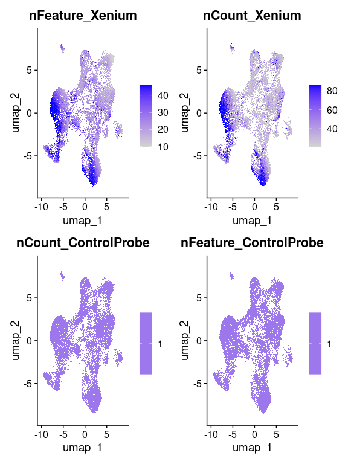

```r
FeaturePlot(ipf3.filtered.xen, features = c("nFeature_Xenium", "nCount_Xenium", "nCount_ControlProbe", "nFeature_ControlProbe"), min.cutoff='q1', max.cutoff='q90')
```

```
Rasterizing points since number of points exceeds 100,000.
To disable this behavior set `raster=FALSE`
Rasterizing points since number of points exceeds 100,000.
To disable this behavior set `raster=FALSE`
Rasterizing points since number of points exceeds 100,000.
To disable this behavior set `raster=FALSE`
Rasterizing points since number of points exceeds 100,000.
To disable this behavior set `raster=FALSE`
Rasterizing points since number of points exceeds 100,000.
To disable this behavior set `raster=FALSE`
Rasterizing points since number of points exceeds 100,000.
To disable this behavior set `raster=FALSE`
```

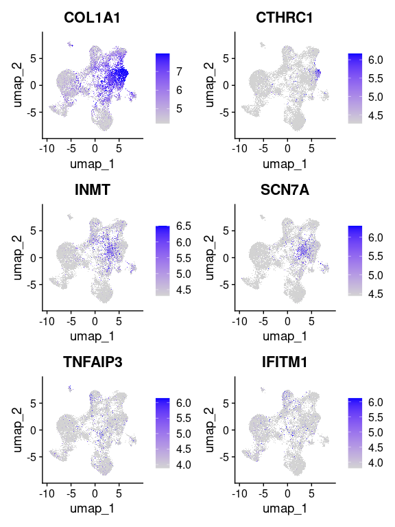

```r
FeaturePlot(ipf3.filtered.xen, features = c("COL1A1", "CTHRC1", "INMT", "SCN7A", "TNFAIP3", "IFITM1"), min.cutoff='q1', max.cutoff='q90')
```

```
Rasterizing points since number of points exceeds 100,000.
To disable this behavior set `raster=FALSE`
Rasterizing points since number of points exceeds 100,000.
To disable this behavior set `raster=FALSE`
Rasterizing points since number of points exceeds 100,000.
To disable this behavior set `raster=FALSE`
Rasterizing points since number of points exceeds 100,000.
To disable this behavior set `raster=FALSE`
Rasterizing points since number of points exceeds 100,000.
To disable this behavior set `raster=FALSE`
Rasterizing points since number of points exceeds 100,000.
To disable this behavior set `raster=FALSE`
```

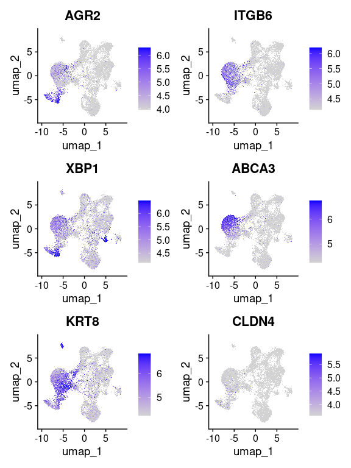

```r
FeaturePlot(ipf3.filtered.xen, features = c("AGR2", "ITGB6", "XBP1", "ABCA3", "KRT8", "CLDN4"), min.cutoff='q1', max.cutoff='q90')
```

```
Rasterizing points since number of points exceeds 100,000.
To disable this behavior set `raster=FALSE`
Rasterizing points since number of points exceeds 100,000.
To disable this behavior set `raster=FALSE`
Rasterizing points since number of points exceeds 100,000.
To disable this behavior set `raster=FALSE`
Rasterizing points since number of points exceeds 100,000.
To disable this behavior set `raster=FALSE`
Rasterizing points since number of points exceeds 100,000.
To disable this behavior set `raster=FALSE`
Rasterizing points since number of points exceeds 100,000.
To disable this behavior set `raster=FALSE`
```

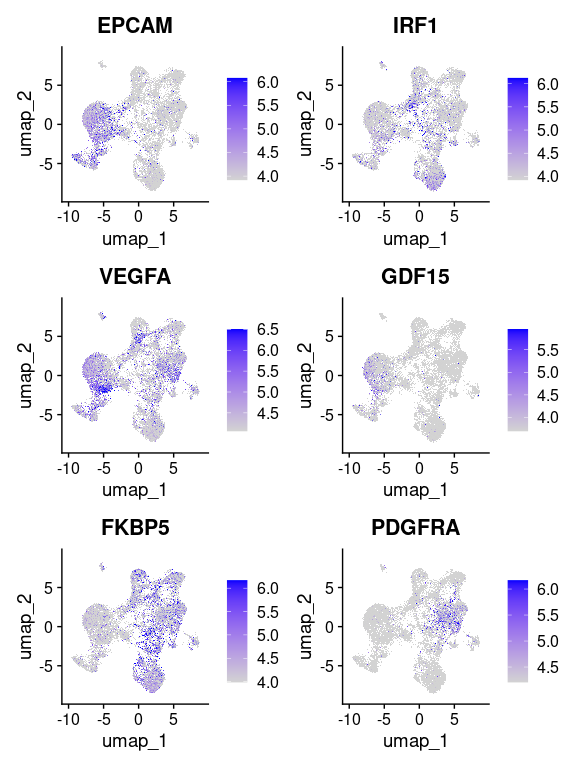

```r
FeaturePlot(ipf3.filtered.xen, features = c("EPCAM", "IRF1", "VEGFA", "GDF15", "FKBP5", "PDGFRA"), min.cutoff='q1', max.cutoff='q90')
```

```r
ipf1.filtered.xen <- RenameIdents(object=ipf1.filtered.xen,
                                  `0`='Unidentified',
                                  `1`='Fib:Alveolar',
                                  `2`='Fib:Fibrotic',
                                  `3`='DATP:NOS',
                                  `4`='Macrophage?',
                                  `5`='Fib:Alv/Inflammed',
                                  `6`='DATP:Fibrotic',
                                  `7`='Airway-like',
                                  `8`='Fib:NOS',
                                  `9`='Fib:NOS',
                                  `10`='Fib:NOS')
ipf1.filtered.xen$named_clusters <- Idents(ipf1.filtered.xen)
```

```
Rasterizing points since number of points exceeds 100,000.
To disable this behavior set `raster=FALSE`
```

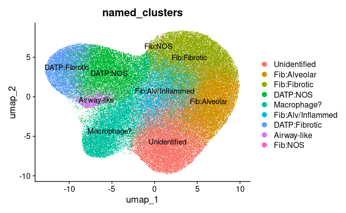

```r
DimPlot(ipf1.filtered.xen, group.by = 'named_clusters', label=T)
```

## Slot names back into the main library

```r
# default identity, the cells that were excluded based on low counts.
ipf3.xen$named_clusters <- 'Low Count'
# Convert assignments in subset to vector (not factor)
clusterIDs <- as.character(ipf3.filtered.xen$named_clusters)
```

[output not shown]

Break down the assignments:

```r
ipf3.xen@meta.data %>% group_by(named_clusters) %>% summarise(no_rows=length(named_clusters))
```

[output not shown]

Update saved object

```r
save(ipf3.xen, file='ipf3.xen.RObj')
```

# Examine data as if spatial

## Generate assignments file for Xenium Explorer

For version 1.2.0, the instructons say:

“Visualize custom cells groups in Xenium Explorer by importing a CSV file specifying cell ids and corresponding group names. Build a CSV file containing each cell id in the first column and the group the cell should be assigned to in the second column. A cell may only be assigned to one group. Not all cells in the dataset need to be included.

Ensure the columns have headers named “cell_id” and “group”.”

This is basically the named_clusters list with a header and saved as a CSV.

```r
scratch <- tibble(cell_id = names(ipf3.xen$named_clusters),
                      group = ipf3.xen$named_clusters)
write.csv(scratch, 'Seurat_named_clusters.csv')
```

## Imaging within Seurat

Found a region within Xenium explorer and figured the coordinates.

```r
cropped.coords <- Crop(ipf3.xen[["fov"]], x = c(2150, 2550), y = c(5650, 5950), coords = "plot")
ipf3.xen[["zoom"]] <- cropped.coords
# visualize cropped area with cell segmentations & selected molecules
DefaultBoundary(ipf3.xen[["zoom"]]) <- "segmentation"
ImageDimPlot(ipf3.xen, fov = "zoom", axes = TRUE, border.color = "white", border.size = 0.1, cols = "polychrome",
    coord.fixed = FALSE, molecules = c("ITGB6", "GDF15", "CTHRC1", "ABCA3", "CLDN4"), nmols = 10000)
```

[output not shown]